# methodsofpredictionfinalassignment_GH1025910_LAST

## Problem Statement💊

As a Datascientist in a pharmaceutical company 🔬 the goal of this project is to develop a predictive model to determine whether patients have Parkinson's disease 🦠 using a comprehensive dataset. This dataset includes

1)Demographic information🚯, 2)lifestyle factors😷, 3)medical history👨‍⚕️, 4)clinical measurements🏥, 5)cognitive and functional assessments🧫, 6)symptoms🦼, and 8)Diagnosis indicator🧪.

By analyzing this data, the aim is to identify key factors associated with Parkinson's disease and create a reliable prediction tool 🏅. This model will assist healthcare professionals in early detection and intervention, potentially improving patient outcomes💉. Additionally, it will provide valuable insights for researchers studying the disease's progression and its impact☢️.

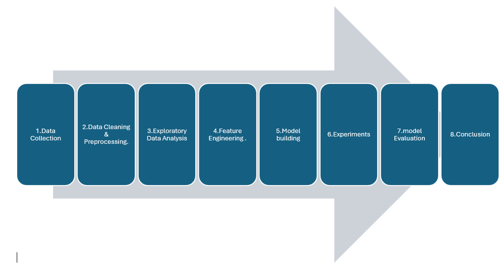

```python
import pandas as p
import numpy as n
import matplotlib.pyplot as px
import seaborn as svs
from sklearn.model_selection import train_test_split
from sklearn.preprocessing import StandardScaler
from imblearn.over_sampling import SMOTE
import tensorflow as tf
from tensorflow import keras as kk
from tensorflow.keras.optimizers import Adam
from tensorflow.keras.layers import BatchNormalization
from keras.regularizers import l2
from sklearn.metrics import  recall_score, f1_score, confusion_matrix
```

## Data collection 📈

```python
## link to the Dataset::'https://www.kaggle.com/datasets/rabieelkharoua/parkinsons-disease-dataset-analysis'👨‍🦼
dfp=p.read_csv('parkinsons_disease_data.csv')
```

```python
dfp.columns
```

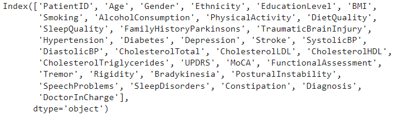

```python
dfp.head()
```

|  | PatientID | Age | Gender | Ethnicity | EducationLevel | BMI | Smoking | AlcoholConsumption | PhysicalActivity | DietQuality | ... | FunctionalAssessment | Tremor | Rigidity | Bradykinesia | PosturalInstability | SpeechProblems | SleepDisorders | Constipation | Diagnosis | DoctorInCharge |
| --- | --- | --- | --- | --- | --- | --- | --- | --- | --- | --- | --- | --- | --- | --- | --- | --- | --- | --- | --- | --- | --- |
| 0 | 3058 | 85 | 0 | 3 | 1 | 19.619878 | 0 | 5.108241 | 1.380660 | 3.893969 | ... | 1.572427 | 1 | 0 | 0 | 0 | 0 | 0 | 0 | 0 | DrXXXConfid |
| 1 | 3059 | 75 | 0 | 0 | 2 | 16.247339 | 1 | 6.027648 | 8.409804 | 8.513428 | ... | 4.787551 | 0 | 1 | 0 | 1 | 0 | 1 | 0 | 1 | DrXXXConfid |
| 2 | 3060 | 70 | 1 | 0 | 0 | 15.368239 | 0 | 2.242135 | 0.213275 | 6.498805 | ... | 2.130686 | 1 | 0 | 0 | 0 | 1 | 0 | 1 | 1 | DrXXXConfid |
| 3 | 3061 | 52 | 0 | 0 | 0 | 15.454557 | 0 | 5.997788 | 1.375045 | 6.715033 | ... | 3.391288 | 1 | 1 | 1 | 0 | 0 | 0 | 1 | 1 | DrXXXConfid |
| 4 | 3062 | 87 | 0 | 0 | 1 | 18.616042 | 0 | 9.775243 | 1.188607 | 4.657572 | ... | 3.200969 | 0 | 0 | 0 | 1 | 0 | 1 | 0 | 0 | DrXXXConfid |

5 rows × 35 columns

```python
dfp.shape
```

```
(2105, 35)
```

#### comments :-🕵️‍♀️

🚩Our dataset consists of 2105 rows and 35 column✔️.

🚩There are float,int,object datatype attributes are present in our dataset , here object datatype needs to be handled before model training.

🚩The "Diagnosis"🏹 attribute is our target column.

🚩Genaral note🌞:: 0 represents "NO" and 1 implies "YES" in our dataset.the columns -(Tremor,Rigidity,Bradykinesia,Posturalinstability,speechproblems,sleepdisorders,consipation,diagnosis) contains this encoded data as observed above.

## Data Cleaning and Preprocessing 🧹

#### check Null values :-

```python
dfp.isnull().sum()>0
```

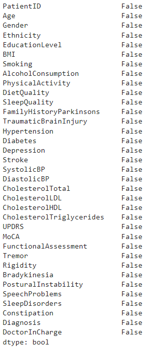

#### duplicate check in our dataset

```python
dfp.duplicated().sum()
```

```
0
```

#### Handling the un-used columns

```python
dfp['DoctorInCharge'].unique()
```

```
array(['DrXXXConfid'], dtype=object)
```

##### dropping the DoctorInCharge column which will be of no use in our analysis:

```python
dfp_new=dfp.copy() # taking the copy of the original data
```

```python
dfp_new.drop('DoctorInCharge',axis=1,inplace=True)
```

```python
print(f'The old dataset:{dfp.shape},\nThe new dataset:{dfp_new.shape} ')
```

```
The old dataset:(2105, 35),
The new dataset:(2105, 34)
```

#### comments :-🕵️‍♀️

🚩 There are no null values as well as there are no duplicated rows observed📝.

🚩 Unnecesary column :DoctorInCharge👩‍⚕️ which has only one unique value is dropped from the main dataset which has no impact on our next steps.

## Exploratory data analysis 🔎

#### 1) To check the Target column Diagnosis is balanced/ imbalanced

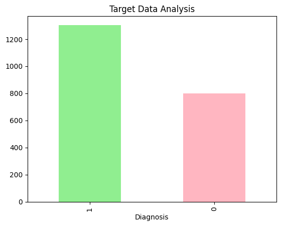

```python
dfp_new['Diagnosis'].value_counts().plot(kind='bar',color={'lightpink','lightgreen'})
px.title('Target Data Analysis');
```

```python
dfp_new['Diagnosis'].value_counts()
```

```
Diagnosis
1    1304
0     801
Name: count, dtype: int64
```

#### comments :-🕵️‍♀️

🚩 The Dataset is imbalanced data set ⚖️,i.e with positive diagnosis are 1304 and negative diagnosis are 801 as show above.we might need to perform any up-sampling or down-sampling techniques in feature engineering.

#### 2) Understanding the diagnosis column relationship with other columns📜:-

```python
grouped=dfp_new.groupby('Diagnosis').mean().T
grouped
```

| Diagnosis | 0 | 1 |
| --- | --- | --- |
| PatientID | 4143.732834 | 4089.279141 |
| Age | 68.635456 | 70.195552 |
| Gender | 0.481898 | 0.499233 |
| Ethnicity | 0.699126 | 0.688650 |
| EducationLevel | 1.332085 | 1.340491 |
| BMI | 26.932601 | 27.379577 |
| Smoking | 0.293383 | 0.298313 |
| AlcoholConsumption | 9.774184 | 10.203948 |
| PhysicalActivity | 4.968954 | 5.045987 |
| DietQuality | 4.997137 | 4.861158 |
| SleepQuality | 7.093457 | 6.937167 |
| FamilyHistoryParkinsons | 0.139825 | 0.149540 |
| TraumaticBrainInjury | 0.097378 | 0.111963 |
| Hypertension | 0.151061 | 0.142638 |
| Diabetes | 0.122347 | 0.164110 |
| Depression | 0.174782 | 0.223926 |
| Stroke | 0.041199 | 0.053681 |
| SystolicBP | 133.868914 | 133.628067 |
| DiastolicBP | 90.882647 | 89.861196 |
| CholesterolTotal | 227.917357 | 226.211859 |
| CholesterolLDL | 125.333531 | 126.648069 |
| CholesterolHDL | 60.255434 | 59.310957 |
| CholesterolTriglycerides | 220.911515 | 224.186832 |
| UPDRS | 72.683695 | 119.064114 |
| MoCA | 17.002809 | 13.921994 |
| FunctionalAssessment | 5.831890 | 4.472364 |
| Tremor | 0.258427 | 0.538344 |
| Rigidity | 0.149813 | 0.315951 |
| Bradykinesia | 0.112360 | 0.266104 |
| PosturalInstability | 0.073658 | 0.178681 |
| SpeechProblems | 0.302122 | 0.290644 |
| SleepDisorders | 0.250936 | 0.241564 |
| Constipation | 0.282147 | 0.305982 |

#### comments :-🕵️‍♀️

🚩The mean value of majority of the attributes values are high in the patients who diagonised as 1 (i.e parkinsons positive) than the value 0, for example we can see 🚹BMI,🚬Smoking,🍺AlcoholConsumtion,🏋️‍♀️PhysicalActivity,Depression,U-P-D-R-S(Unified Parkinson's Disease Rating Scale score) which is main scores for parkinsons,Tremor,Rigidity,🐢bradykinesia (slowness of movement),Constipation are higher for the positive(1) data.

## Feature Engineering 🪛

#### splittingup the data into target(y) and feautures(x)

```python
M= dfp_new.drop(columns='Diagnosis',axis=1)
n=dfp_new['Diagnosis']
```

#### Splitup data into trainingdata and testing sets

```python
X_training, X_testing, y_training, y_testing = train_test_split(M, n, test_size=0.22, random_state=2)
```

```python
print(f'1.X_trainshape::{X_training.shape} \n\n2.X_testshape::{X_testing.shape} \n\n3.y_trainshape::{y_training.shape} \n\n4.y_testshape::{y_testing.shape}')
```

```
1.X_trainshape::(1641, 33)

2.X_testshape::(464, 33)

3.y_trainshape::(1641,)

4.y_testshape::(464,)
```

#### Balancing the dataset using SMOTE oversampling method

```python
smote = SMOTE(random_state=42)
X_oversampled, y_oversampled = smote.fit_resample(X_training, y_training)
```

```python
print(f'1.X_resampled::{X_oversampled.shape} \n\n2.y_resampled::{y_oversampled.shape}')
```

```
1.X_resampled::(2064, 33)

2.y_resampled::(2064,)
```

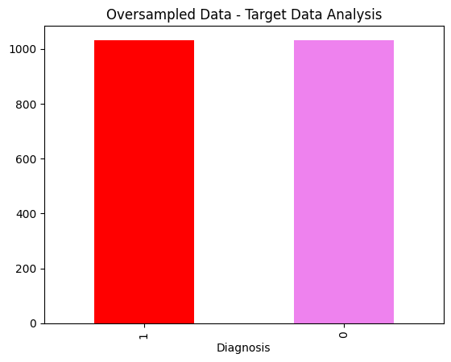

```python
y_oversampled.value_counts().plot(kind='bar',color={'red','violet'})
px.title('Oversampled Data - Target Data Analysis');
```

### Standardize the data

```python
from re import X
scaler=StandardScaler()
X_train_standard=scaler.fit_transform(X_oversampled)
x_test_standard=scaler.transform(X_testing)
```

```python
X_oversampled.shape,X_train_standard.shape,x_test_standard.shape,y_oversampled.shape,y_training.shape,y_testing.shape
```

```
((2064, 33), (2064, 33), (464, 33), (2064,), (1641,), (464,))
```

## model building 🤖

#### ⓪ Test run 0:- Basic Configerations,

Experimenting : Running with the basic settings i.e one Flatten,Hidden & Output layers and checking the performance of the model.

```python
tf.random.set_seed(3) # to get the consistant accuracy_score irrespective of runs,
```

#### settingup the layers

```python
basemodel = kk.Sequential([
                        kk.layers.Flatten(input_shape=(33,)),

                        kk.layers.Dense(20,activation='relu'),

                        kk.layers.Dense(2,activation='sigmoid')

])
```

#### compiling the neural network

```python
basemodel.compile(optimizer='adam',

               metrics=['accuracy'],

              loss='sparse_categorical_crossentropy', # as our target have two labels, 0 and 1



             )
```

#### Training the Neural network:-

```python
historyNN= basemodel.fit(X_train_standard,y_oversampled,validation_split=0.1,epochs=10)
```

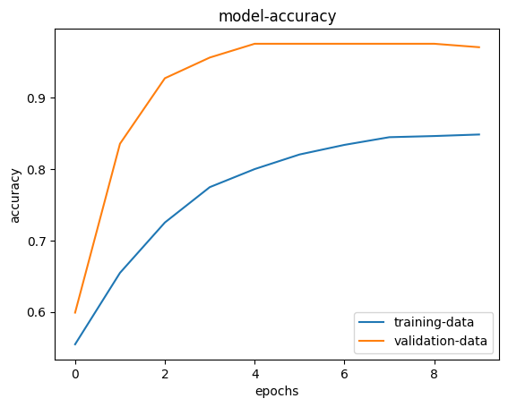

```python
# Visualising Accuracy & loss
px.plot(historyNN.history['accuracy'])
px.plot(historyNN.history['val_accuracy'])

px.title('model-accuracy')
px.ylabel('accuracy')
px.xlabel('epochs')

px.legend(['training-data','validation-data'],loc ='lower right');
```

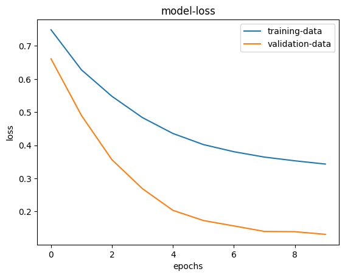

```python
px.plot(historyNN.history['loss'])
px.plot(historyNN.history['val_loss'])

px.title('model-loss')
px.ylabel('loss')
px.xlabel('epochs')

px.legend(['training-data','validation-data'],loc ='upper right');
```

##### Accuracy of models on testdata

```python
loss_train0 ,accuracy_trail0 = basemodel.evaluate(x_test_standard,y_testing)
```

```python
print(x_test_standard.shape)
print(x_test_standard[0])
```

```
(464, 33)
[-0.38568426  1.72930626  1.13949154  2.51192289 -1.45187322  0.87390106
 -0.57735027 -0.05822226 -1.2657691   1.38478127  1.45519173 -0.36444626
 -0.30341966 -0.3695455  -0.38629068 -0.44330773 -0.20597146  0.3025043
  0.16792201  0.8431123  -1.56126946  1.58296049 -1.24190138  0.44972056
 -0.41375772  0.11103034 -0.75075719 -0.50620015 -0.45110813  2.89513699
 -0.58406387 -0.51675428 -0.58779414]
```

```python
Y_pred=basemodel.predict(x_test_standard)
```

#### model confident Analysis :-

```python
#model confident Analysis :-
print(Y_pred.shape)
print (f'The model is confident that the output is {Y_pred[0][0]*100} %  will be 0 and {Y_pred[0][1]*100} % will be 1')
```

```
(464, 2)
The model is confident that the output is 26.28341019153595 %  will be 0 and 53.67431640625 % will be 1
```

## Experimentation 💹🛠

#### Test run 01:- Increasing the Number of the Neurons:-🧠

Experimenting:: More neurons provides the network with the capacity to learn more detailed features from the input data, potentially improving accuracy.

```python
model01 = kk.Sequential([
    kk.layers.Flatten(input_shape=(33,)),

    kk.layers.Dense(50, activation='relu'),  # Increased neurons

    kk.layers.Dense(2, activation='sigmoid')

])

# compiling the Neural network
model01.compile(optimizer='adam',


                metrics=['accuracy'],

              loss='sparse_categorical_crossentropy'

              )
```

```python
# Training the Neural network:-
historyNN01= model01.fit(X_train_standard,y_oversampled,validation_split=0.1,epochs=15)
```

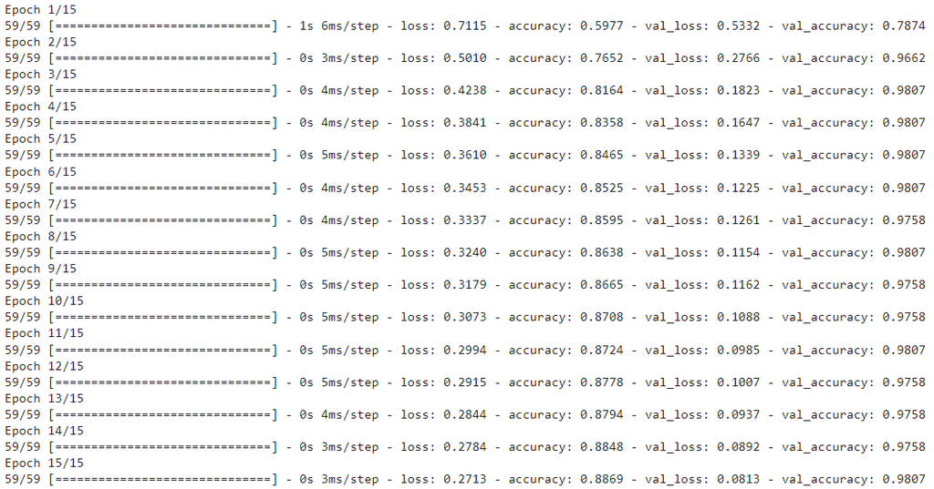

```python
# Accuracy of models on testdata test run 1:-
loss_test01 ,accuracy_test01 = model01.evaluate(x_test_standard,y_testing)
```

#### Test run 2: Adding More Hidden Layers :- 🔎

Experimenting :-Adding more hidden layers can increase the depth of learning the network, allowing it to learn more complex representations of the data.

```python
# setting up the layers of Neural Network
model2 = kk.Sequential([

    kk.layers.Flatten(input_shape=(33,)),

    kk.layers.Dense(20, activation='relu'),

    kk.layers.Dense(20, activation='relu'),
    # Additional hidden layer
    kk.layers.Dense(2, activation='sigmoid')
])
# compiling
model2.compile(optimizer='adam',

               metrics=['accuracy'],

              loss='sparse_categorical_crossentropy'

              )

# Training
historyNN02 = model2.fit(X_train_standard,y_oversampled, validation_split=0.1, epochs=15)
```

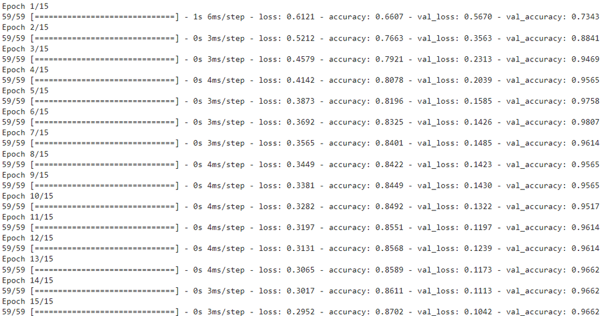

```python
# Accuracy of models on testdata test run 2:-
loss_test02 ,accuracy_test02 = model2.evaluate(x_test_standard,y_testing)
```

#### Test run 3: Changing Activation Functions :- 🔋

Experimenting :-Using different activation functions can help the network learn different types of patterns. For example, using tanh instead of relu.

```python
# setting up the layers
model3 = kk.Sequential([

    kk.layers.Flatten(input_shape=(33,)),

    kk.layers.Dense(20, activation='tanh'),
    # Changed activation function
    kk.layers.Dense(2, activation='sigmoid')

])

# compiling
model3.compile(optimizer='adam',

               metrics=['accuracy'],

              loss='sparse_categorical_crossentropy'

              )

# Training
historyNN03 = model3.fit(X_train_standard,y_oversampled, epochs=15, validation_split=0.1)
```

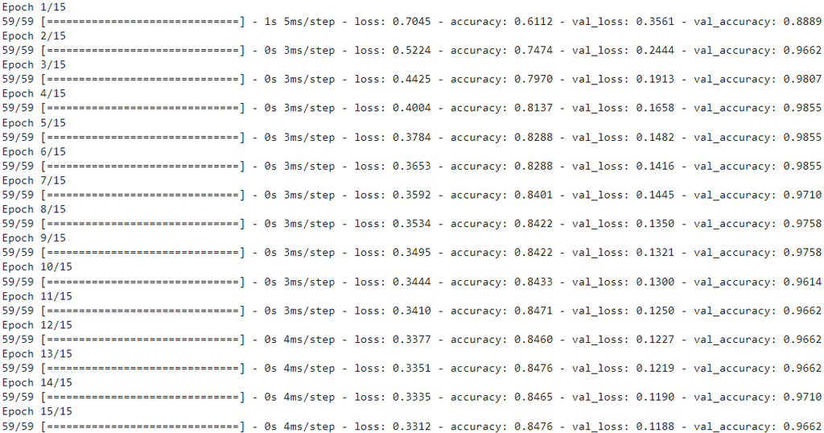

```python
# Accuracy of models on testdata test run 3:-
loss_test03 ,accuracy_test03 = model3.evaluate(x_test_standard,y_testing)
```

#### Test run 4: Using Dropout for Regularization :- 🔮

Experimenting :-Adding dropout layers can help in preventing overfitting by random setting a fraction of input units to '0' during training.

```python
# setting up the layers of Neural Network
model4 = kk.Sequential([

    kk.layers.Flatten(input_shape=(33,)),

    kk.layers.Dense(20, activation='relu'),

    kk.layers.Dropout(0.5),
    # Dropout layer

    kk.layers.Dense(2, activation='sigmoid')

])
# compiling the Neural network
model4.compile(metrics=['accuracy'],

               optimizer='adam',

              loss='sparse_categorical_crossentropy'

              )

# Training the Neural network
historyNN04 = model4.fit(X_train_standard,y_oversampled,epochs=15, validation_split=0.1 )
```

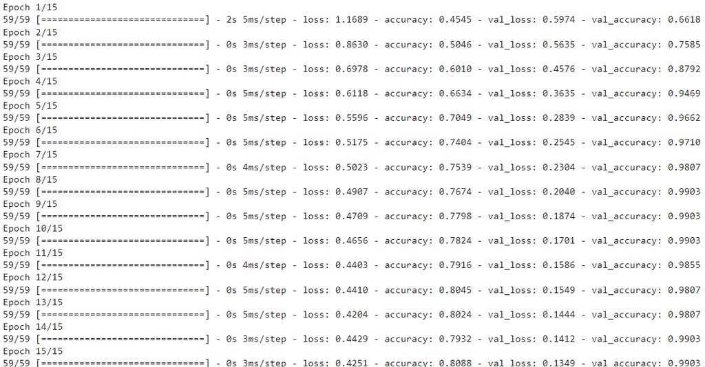

```python
# Accuracy of models on testdata test run 4:-
loss_test04 ,accuracy_test04 = model4.evaluate(x_test_standard,y_testing)
```

#### Test run 5: Changing the Optimizer :- 🆕

Experimenting :-Trying different optimizers like RMSprop or SGD can help the model converge faster or find better minima.

```python
# setting
model5 = kk.Sequential([

    kk.layers.Flatten(input_shape=(33,)),

    kk.layers.Dense(20, activation='relu'),

    kk.layers.Dense(2, activation='sigmoid')
])
# compiling
model5.compile(optimizer='RMSprop',

               metrics=['accuracy'],

               # Changed optimizer
              loss='sparse_categorical_crossentropy',

              )

# Training
historyNN05 = model5.fit(X_train_standard,y_oversampled,epochs=15, validation_split=0.1 )
```

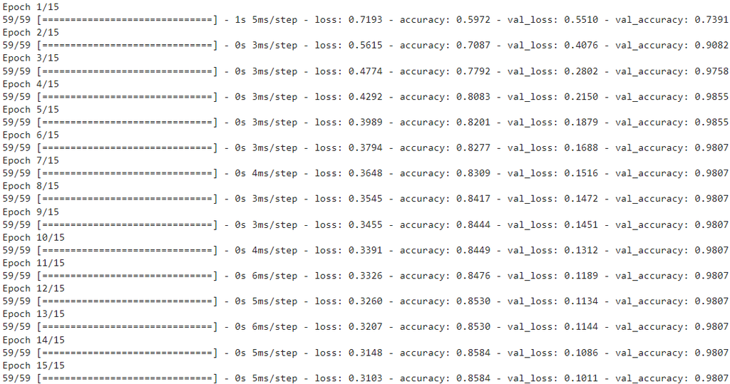

```python
# Accuracy of models on testdata test run 5:-
loss_test05 ,accuracy_test05 = model5.evaluate(x_test_standard,y_testing)
```

Experimenting :-Modifying the learning rate can help the optimizer find the minimum more efficiently.

```python
# setting
model6 = kk.Sequential([

    kk.layers.Flatten(input_shape=(33,)),

    kk.layers.Dense(20, activation='relu'),

    kk.layers.Dense(2, activation='sigmoid')
])
# compiling
model6.compile(optimizer=Adam(learning_rate=0.001),

                metrics=['accuracy'],

               # Adjusted learning rate
              loss='sparse_categorical_crossentropy',

             )

# Training the Neural network
historyNN06 = model6.fit(X_train_standard,y_oversampled,epochs=15, validation_split=0.1 )
```

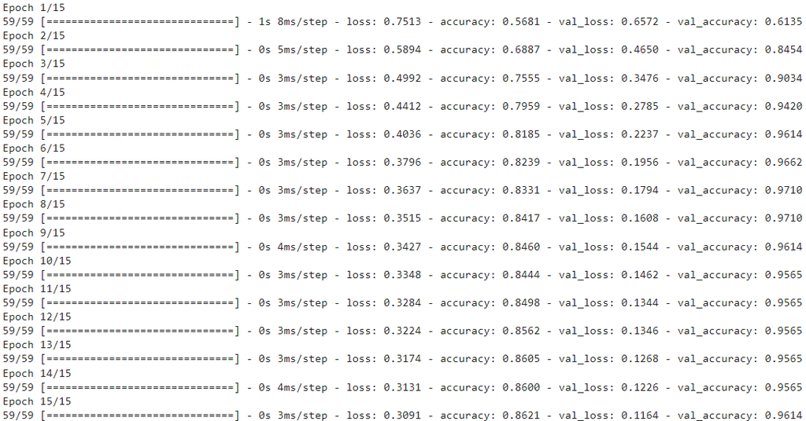

```python
# Accuracy of models on testdata test run 6:-
loss_test06 ,accuracy_test06 = model6.evaluate(x_test_standard,y_testing)
```

#### Test run 7: Using Batch Normalization :- ⚓

Experimenting :-Adding batch normalization can stabilize and speed up the training process.

```python
# setting
model7 = kk.Sequential([

    kk.layers.Flatten(input_shape=(33,)),

    kk.layers.Dense(20, activation='relu'),

    BatchNormalization(),

    # Batch normalization layer
    kk.layers.Dense(2, activation='sigmoid')

])
# compiling
model7.compile(optimizer='adam',

               metrics=['accuracy'],

              loss='sparse_categorical_crossentropy'

              )

# Training
historyNN07 = model7.fit(X_train_standard,y_oversampled,epochs=15, validation_split=0.1 )
```

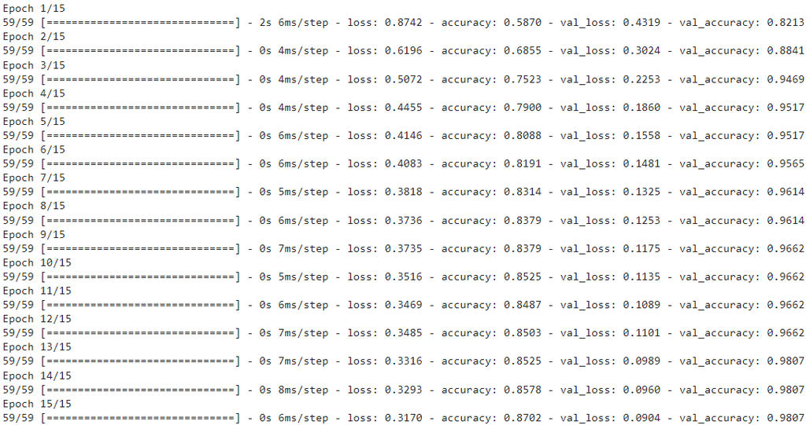

```python
# Accuracy of models on testdata test run 7:-
loss_test07 ,accuracy_test07 = model7.evaluate(x_test_standard,y_testing)
```

#### Test run 8: L2 Regularization (Weight Regularization):- 🌐

Experimenting :-L2 regularization penalizes large weights, promoting a simpler model and reducing overfitting, which can improve generalization to unseen data.

```python
model8 = kk.Sequential([
    kk.layers.Flatten(input_shape=(33,)),

    kk.layers.Dense(20, activation='relu', kernel_regularizer=l2(0.01)),
    # Added L2 regularization

    kk.layers.Dense(2, activation='sigmoid')
])

model8.compile(optimizer='adam',

               metrics=['accuracy'],

               loss='sparse_categorical_crossentropy'


              )

historyNN08 = model8.fit(X_train_standard,y_oversampled,epochs=20, validation_split=0.1 )
```

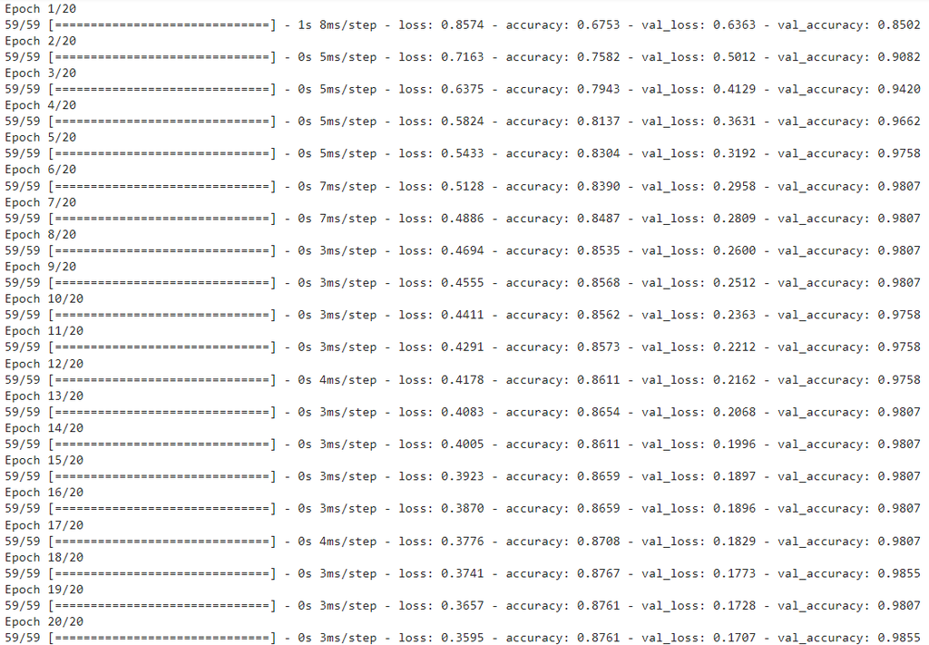

```python
# Accuracy of models on testdata test run 8:-
loss_test08 ,accuracy_test08 = model8.evaluate(x_test_standard,y_testing)
```

Experimenting :-Using softmax activation and sparse-categorical crossentropy loss-function is suitable for multiclass classification tasks, ensuring proper handling of class probabilities.

```python
model9 = kk.Sequential([
    kk.layers.Flatten(input_shape=(33,)),

    kk.layers.Dense(20, activation='relu'),

    kk.layers.Dense(2, activation='softmax')  # Changed activation to 'softmax' for multi-class
])

model9.compile(optimizer='adam',

               metrics=['accuracy'],

               loss='sparse_categorical_crossentropy'


              )

historyNN09 = model9.fit(X_train_standard,y_oversampled,epochs=15, validation_split=0.1 )
```

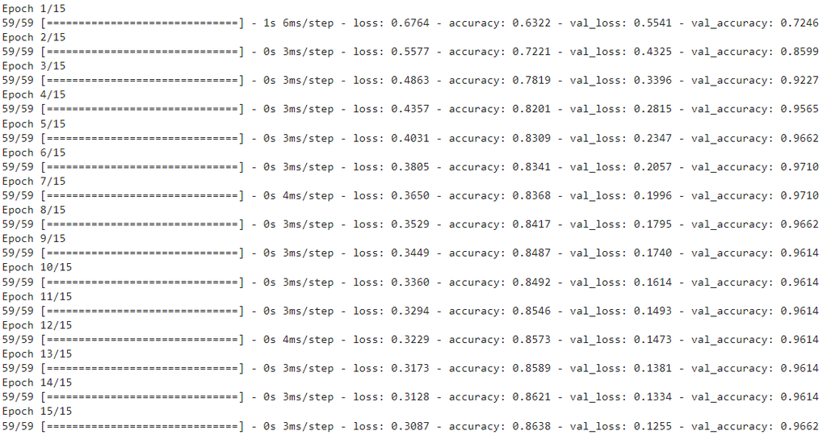

```python
# Accuracy of models on testdata test run 9:-
loss_test09 ,accuracy_test09 = model9.evaluate(x_test_standard,y_testing)
```

#### Test run 10: Tuning Number of Epochs:- 🎲

Experimenting :-Increasing ,number of epochs allows the model more opportunities to learn from the data, potentially improves the accuracy over time. However, this should be carefully monitored to avoids the overfitting.

```python
model10 = kk.Sequential([

    kk.layers.Flatten(input_shape=(33,)),

    kk.layers.Dense(20, activation='relu'),

    kk.layers.Dense(2, activation='sigmoid')

])

model10.compile(optimizer='adam',

                 metrics=['accuracy'],

                loss='sparse_categorical_crossentropy'

               )

historyNN10 = model10.fit(X_train_standard,y_oversampled,epochs=30, validation_split=0.1 )  # Increased epochs to 20
```

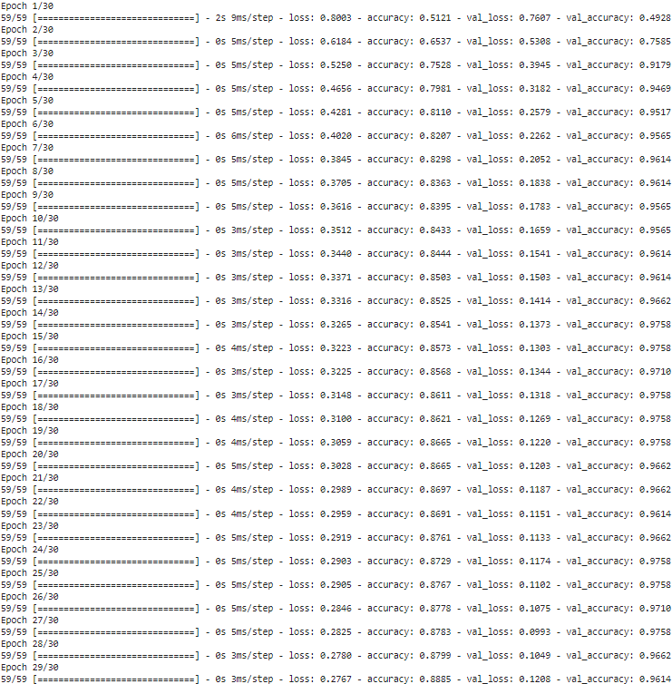

```python
# Accuracy of models on testdata test run 9:-
loss_test10,accuracy_test10 = model10.evaluate(x_test_standard,y_testing)
```

## MODEL EXPERIMENTS SUMMARY 🥇🥈🥉

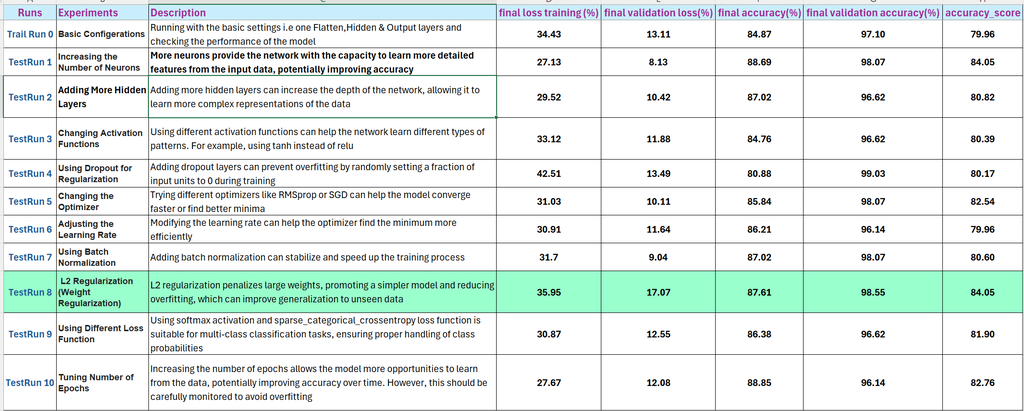

## Model Evaluation 🎢

```python
print(f'Trail-run: 0 :: {accuracy_trail0}')
print(f'Test-run: 1 :: {accuracy_test01}')
print(f'Test-run: 2 :: {accuracy_test02}')
print(f'Test-run: 3 :: {accuracy_test03}')
print(f'Test-run: 4 :: {accuracy_test04}')
print(f'Test-run: 5 :: {accuracy_test05}')
print(f'Test-run: 6 :: {accuracy_test06}')
print(f'Test-run: 7 :: {accuracy_test07}')
print(f'Test-run: 8 :: {accuracy_test08}')
print(f'Test-run: 9 :: {accuracy_test09}')
print(f'Test-run: 10:: {accuracy_test10}')
```

```
Trail-run: 0 :: 0.7995689511299133
Test-run: 1 :: 0.8405172228813171
Test-run: 2 :: 0.8081896305084229
Test-run: 3 :: 0.8038793206214905
Test-run: 4 :: 0.8017241358757019
Test-run: 5 :: 0.8254310488700867
Test-run: 6 :: 0.7995689511299133
Test-run: 7 :: 0.806034505367279
Test-run: 8 :: 0.8405172228813171
Test-run: 9 :: 0.818965494632721
Test-run: 10:: 0.8275862336158752
```

```python
# For reference- Accuracy of models on testdata test run 1:-
loss_test01 ,accuracy_test01 = model01.evaluate(x_test_standard,y_testing)
print(loss_test01,accuracy_test01)
```

```
0.3751121163368225 0.8405172228813171
```

#### Visualising Accuracy and loss for the best model i.e model8(L2 Regularization)📊

[figure not shown]

```python
px.plot(historyNN08.history['accuracy'],color='red')
px.plot(historyNN08.history['val_accuracy'],color='green')

px.title('model-accuracy')
px.ylabel('accuracy')
px.xlabel('epochs')

px.legend(['training-data','validation-data'],loc ='lower right');
```

[figure not shown]

```python
px.plot(historyNN08.history['loss'],color='blue')
px.plot(historyNN08.history['val_loss'],color='orange')

px.title('model-loss')
px.ylabel('loss')
px.xlabel('epochs')

px.legend(['training-data','validation-data'],loc ='upper right');
```

#### Recall score(TPR) :-

📞 Recall score helps here because it helps in finding all relavant cases within a dataset , in disease detection missing positive cases(i.e false negatives) is not acceptable in real world scenario and it might causes major loss to the company.

```python
# Making predictions
y_pred_probable = model8.predict(x_test_standard)
y_pred = n.argmax(y_pred_probable, axis=1)
```

```python
recall = recall_score(y_testing, y_pred)
```

```python
print(f'The Recall score of the model is ={n.round(recall*100,2)} percent')
```

```
The Recall score of the model is =88.24 percent
```

### Note-our model correctly identifies 88.24% of actual postive cases in our given dataset out of all positive instances.

#### F1_score :-🚀

As our dataset is imbalanced as observed earlier,F1 score 🚄 is useful in dealing with imbalanced dataset and gives a metric that balances both precision and recall

```python
f1 = f1_score(y_testing, y_pred)
```

```python
print(f'The F1 score of the model is ={n.round(f1*100,2)} percent')
```

```
The F1 score of the model is =85.56 percent
```

### Note-The F1 score is 85.56% it indicates there is good balance between precision an recall suggesting our model is good in identifying both postive and negative cases.

#### Confusion matrix ⛳

```python
confu_matrix = confusion_matrix(y_testing, y_pred)
```

```python
print(confu_matrix)
```

[output not shown]

## Conclusion ✅

🚩 Our Dataset was a imbalanced dataset and we have used Oversampling method(SMOTE) for our validations.

🚩 we have conducted 1 trail run and 10 different test runs with many permutations and combinations for our analysis in that, using L2 Regularization provided best results i.e 84.05% of accuracy score ,88.24 % of Recall score and 85.56% of F1 score.

🚩Limitations - As we choose the model with L2 Regularization it is possible that the model might memorize the data and which can lead to over fitting condition by increasing the complexity of the model increases the model's instability , there might be a requirement of more data to train properly & efficiently and might require further hyperparameter tuning like early stopping , learning rate and using regularization techniques.